# Combining hierarchical models and habitat data improves assessment of data limited salmon stocks

Marine and Coastal Fisheries Paper analysis

W.I. Atlas, D.M. Glaser, B.M. Connors, C.A. Holt, D.T. Selbie, S. Cox-Rogers, C. Carr-Harris, E. Hertz, and J.W. Moore.

# Background

### Load data

Read in the PR data and the time series of stock recruit data then join into 1 big dataframe. $S_{MAX_{PR}}$ and error estimates are calculated over here.

### Plot data

Make some plots to see the data we’re working with.

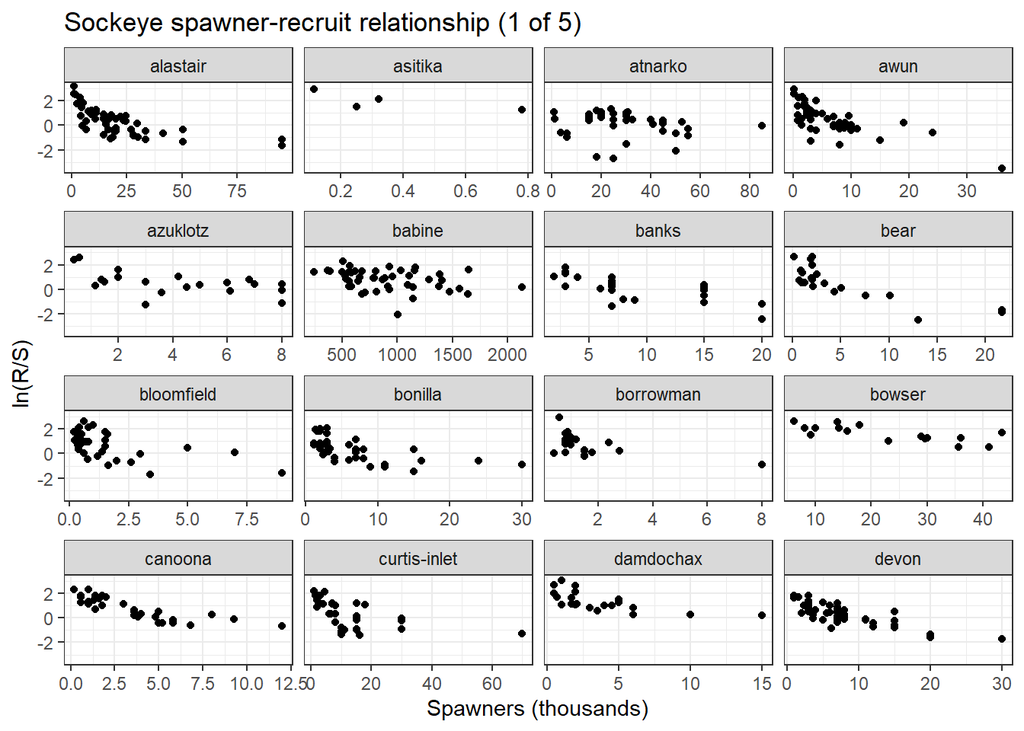

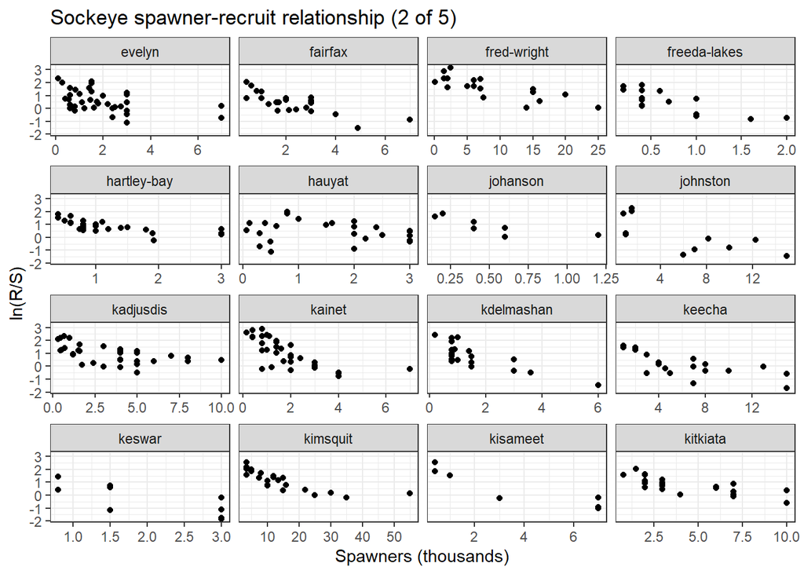

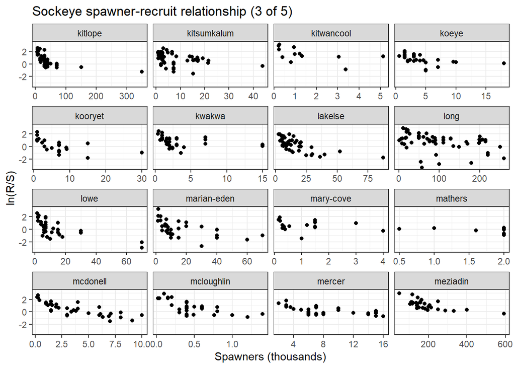

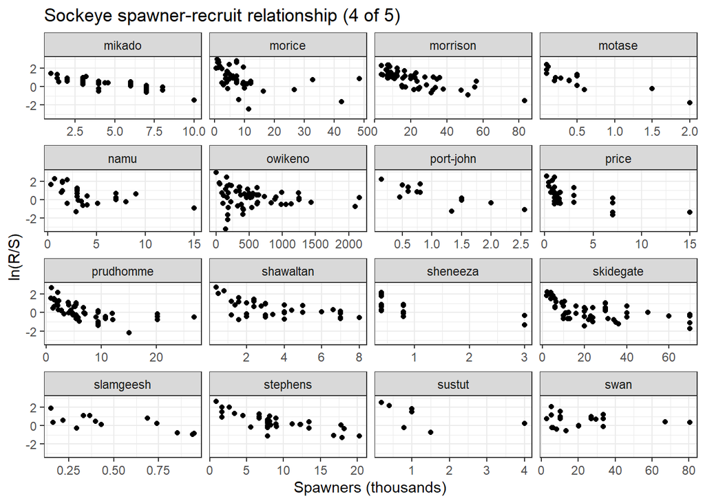

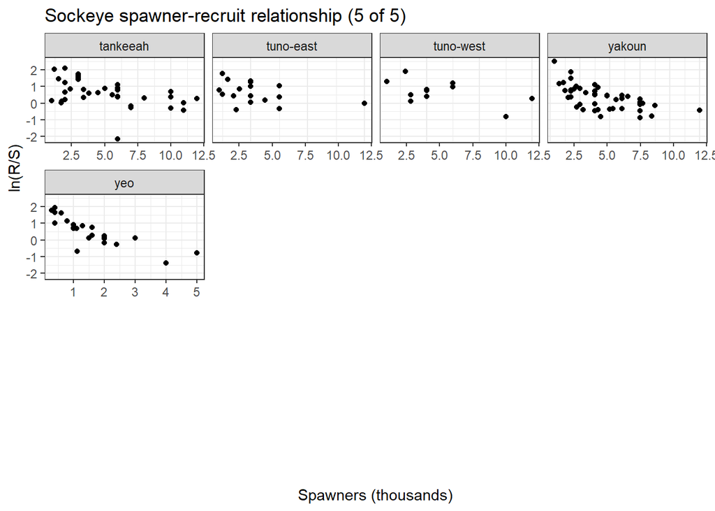

# Modelling

We’re going to fit Ricker stock recruit relationships (i.e. variations of $log(R/S) = log(\alpha) - \beta*S$) in a Bayesian framework with different priors and hierarchical structures to see which fit best. In short, we’ll compare different groupings of hierarchical $\alpha$, uninformative/informative priors based on biogeoclimatic zones and photosynthetic rates. These will be fit in Stan via the `rstan` package where we’ll use default options in the `stan()` function.

Models took several forms:

**1.** Independent models fit to each population with uninformative priors  
**2.** Uninformative $\beta$ priors fit to each population with uninformative hierarchical $\alpha$(s) where:  
**2a.** $\alpha$ is ungrouped and drawn from a distribution across all 69 populations OR  
**2b.** $\alpha$s categorically grouped by biogeoclimatic zone (n=3) and drawn from that group’s distribution.  
**3.** Fits for each population with uninformative $\alpha$, and informative $\beta$ based on $S_{MAX_{PR}}$ estimates  
**4.** Informative, hierarchical $\alpha$(s) based on model performance in model 2 (i.e. grouped $\alpha$s or not), with informative priors on data based on $S_{MAX_{PR}}$.

## Extract draws, get $S_{MSY}$

After extracting draws we can look at regional productivity by model.

And also look at $S_{MSY}$ varied between the top 2 models. This is some data we’ll use for figure 1.

# Figures

### Figure 1

Difference in CV since CVs are standardized

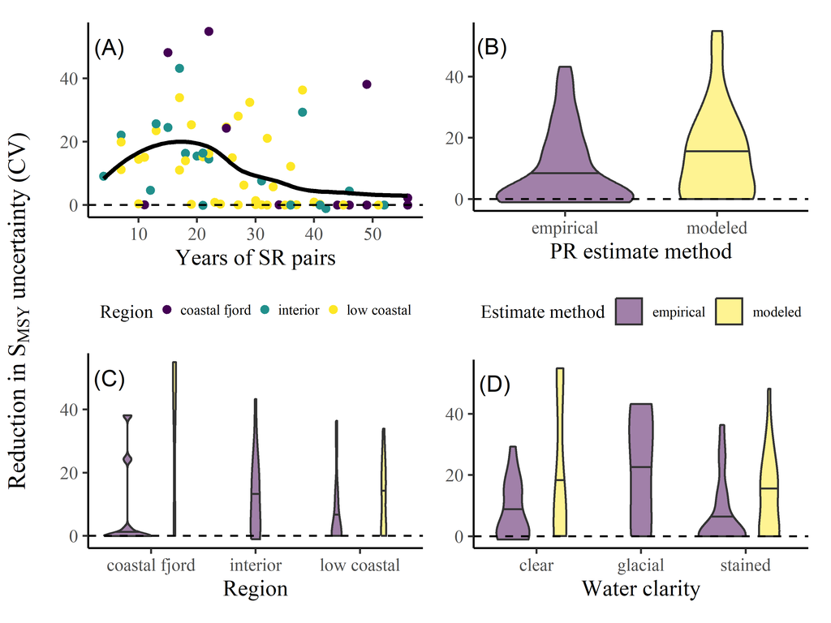

### Figure 2

Percent differences (i.e. bias) relative to the full data m4 median.

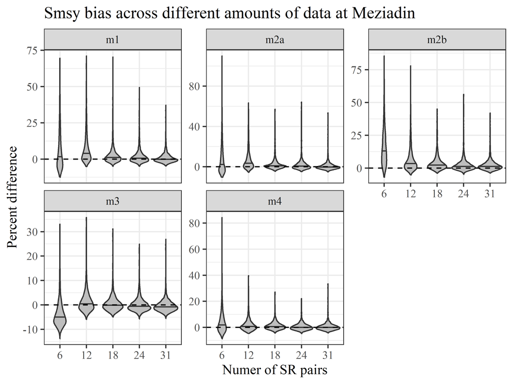

### Figure 3

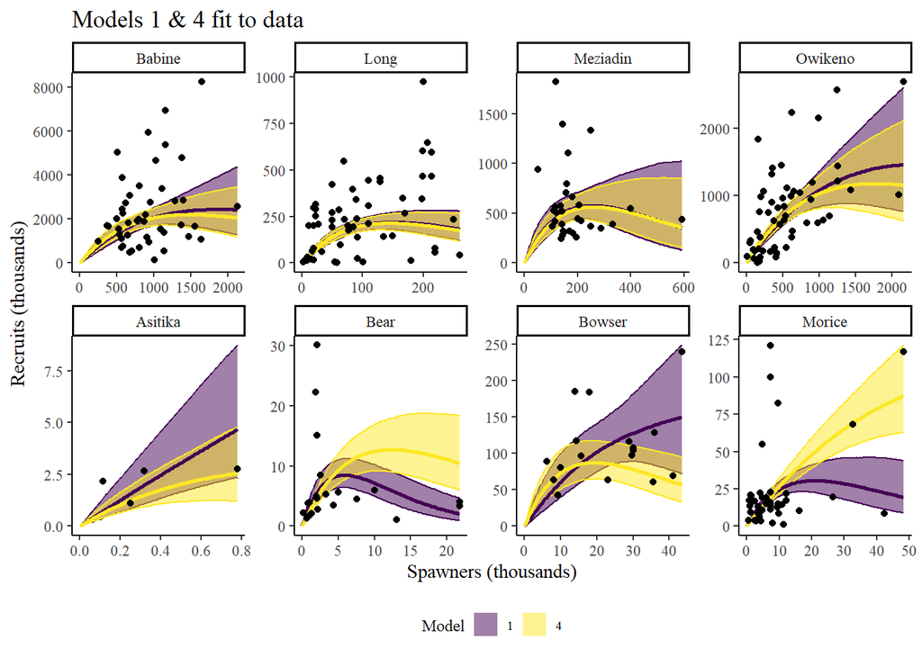

[figure not shown]